## Data Visualization

In this course, we will talk about the importance of **properly visualizing your data** and we will explore different **visualization tools** and **charts** that we can use.

# I. Introduction to data visualization

## I.1. Bad dataviz is wrong

Let's play a game: **what is wrong with this chart?**

[figure not shown]

**Answer**: Axis should start at 0

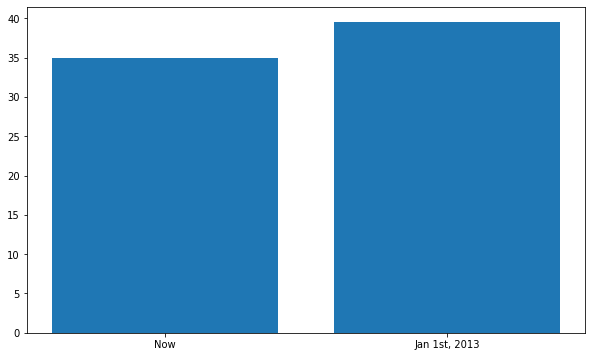

```python
plt.figure(figsize=(10,6))
plt.bar(["Now", "Jan 1st, 2013"], [35, 39.5])
plt.show()
```

**What is wrong with this chart?**

[figure not shown]

**Answer**: Cumulative is misleading, it's always growing. And no y axis label is not clear.

[figure not shown]

**Answer**: Global warming is supposed to happen over a large period of time. The period shown should be long enough.

[figure not shown]

**Answer**: `Apple` (19.5%) looks bigger than `Other` (21.2%): comparing angle is hard.

On top of that, 3D volumes are misleading: they false data-ink ratio (see below).

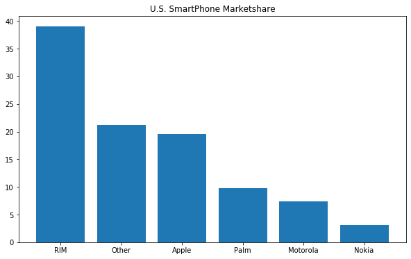

```python
plt.figure(figsize=(10,6))
plt.bar(["RIM", "Other", "Apple", "Palm", "Motorola", "Nokia"],
        [39.0, 21.2, 19.5, 9.8, 7.4, 3.1])
plt.title("U.S. SmartPhone Marketshare")
plt.show()
```

## I.2. Good dataviz is impactful and insightful

### The 7 bridges of Königsberg

There is a famous puzzle called the **[7 bridges of Königsberg](https://en.wikipedia.org/wiki/Seven_Bridges_of_Königsberg)**. The goal is the following:

Find a walk through the city that crosses each of those bridges once and only once.

[figure not shown]

With the right reprensentation, the problem is almost solved, using graph theory.

> A bit of history: Euler used this problem as foundation of the graph theory

[figure not shown]

### The Napoleon's Russian campaign of 1812

[figure not shown]

### Other nice dataviz

**Example**: [@instachaaz](http://www.instagram.com/instachaaz)

[figure not shown]

**Example**: New York Times - ex: "First Leaf" Appearence 🍀

[figure not shown]

# II. Data viz tools

## II.1. Choosing the right chart

Data visualization is all about **storytelling**: what is your message?

An histogram will highlight something different than a scatter plot, that will tell a different story than a line chart, etc.

Here are few questions to help you choose your visualization:

- Are you trying to answer a question (e.g. are the Amazon orders growing over time)? To confirm an hypothesis (e.g. is global warming real)? To convey a message (e.g. should you buy Tesla shares **now**)?
- What would be the best chart to do so?
- What data do you need to draw this chart?
- Collect this data if needed
- Draw your chart

A good framework to determine which chart to choose:

[figure not shown]

Similarly, you can answer the questions above interactively here: http://whichgraph.com/

## II.2. The data-ink ratio

The **Data-Ink ratio** is a concept introduced by Edward Tufte, the expert whose work has contributed significantly to designing effective data visualizations.

In his 1983 book, *The Visual Display of Quantitative Data*, he stated the goal:

> Above all else, show the data.

> *Tufte, 1983*

He then defined the **data-ink ratio** as the proportion of ink (or pixels) that is used to present actual data compared to the total amount of ink (or pixels) used in the whole display.

$$ \text{Data Ink Ratio} = \frac{\text{Data Ink}}{\text{Total ink used in graphic}} $$

This does not respect the **Data-Ink Ratio** rule:

[figure not shown]

This is better

[figure not shown]

Even better if the message is to focus on a trend:

[figure not shown]

# III. Matplotlib

[figure not shown]

`matplotlib` is the **main data visualization library of Python**. It allows you to create charts with a lot of parameters options. Many other data visualization libraries exist though.

You can search online for what you want to create beforehand if needed:

- https://matplotlib.org/
- https://python-graph-gallery.com

We import it the following way:

```python
import matplotlib.pyplot as plt
```

## III.1. Chart basics

Let's explore the principal charts with `matplotlib`. We'll start by exploring the anatomy of a **figure** and how to create one in `matplotlib`.

[figure not shown]

#### Decorating your plot

You can then detail properly:

- the title of the figure: `plt.title('Chart Title')`
- the axis label: with `plt.xlabel("X-title")` and `plt.ylabel("Y-title")`

As you will see in the documentation, matplotlib offers a variety of parameters in these functions to custom your charts as you wish.

After all that, you call the function `plt.show()` in order to draw the figure.

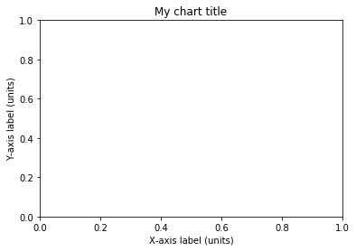

```python
# Adding axis labels
plt.xlabel('X-axis label (units)')
plt.ylabel('Y-axis label (units)')

# Adding a title and format a title for our chart
plt.title('My chart title')

# At the end, we display the plot with `plt.show()`
plt.show()
```

#### `plt.figure`

When creating a chart with `pyplot`, it creates automatically a figure (container for your charts).

But you can create it yourself in order to, for example, specify the size of your figure with `figsize=(width, height)` with dimensions in inches.

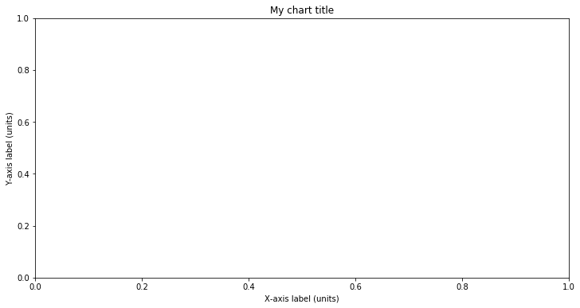

```python
# Same as before, but first we create a figure (container for your charts)
# with an custom size in inches
plt.figure(figsize=(12,6))

# Adding axis labels
plt.xlabel('X-axis label (units)')
plt.ylabel('Y-axis label (units)')

# Adding a title and format a title for our chart
plt.title('My chart title')

# At the end, we display the plot with `plt.show()`
plt.show()
```

## III.2. Basic plot

#### `plt.plot`

One of the most classical chart: `plt.plot`.

Draws lines between the data points. Especially useful with time series, or to display trends.

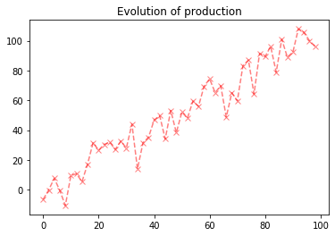

```python
import numpy as np
# Simulate a trend with noise
x = np.arange(0, 100, 2)
y = x + np.random.randn(50) * 10

plt.plot(x, y,
         marker='x', # Markers used for your data points - try 'o', '+' for example
         linestyle='--', # Style used for your lines - try '-'
         color='r', # 'r' for red, 'g' for green...
         alpha=0.5)

plt.title("Evolution of production")
plt.show()
```

> N.B.: For more information about the available colors, go [here](https://matplotlib.org/3.1.0/gallery/color/named_colors.html).

## III.2. Bar chart

#### `plt.bar`

You can build a bar chart with `plt.bar`.

It is mostly used to compare data with a few items of few categories.

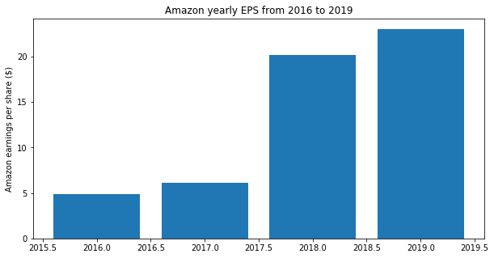

```python
plt.figure(figsize=(10, 5))

year = np.array([2016, 2017, 2018, 2019])
amzn_eps = [4.9, 6.15, 20.14, 23.01]

plt.bar(x=year, height=amzn_eps)
plt.title('Amazon yearly EPS from 2016 to 2019')
plt.ylabel("Amazon earnings per share ($)")
plt.show()
```

One can make more complex bar plots with several values to display, using both the `label` parameter and the `plt.legend()` function:

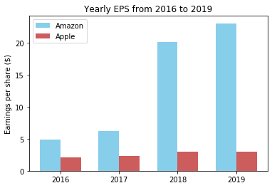

```python
aapl_eps = [2.08, 2.30, 2.98, 2.97]

width = 0.35
plt.bar(year-width/2, amzn_eps, width, color='SkyBlue', label='Amazon')
plt.bar(year+width/2, aapl_eps, width, color = 'IndianRed', label = 'Apple')
plt.title('Yearly EPS from 2016 to 2019')
plt.ylabel("Earnings per share ($)")
plt.xticks(year)
plt.legend()
plt.show()
```

## III.3. Histogram

#### `plt.hist`

You can easily draw histograms using the `plt.hist` function of matplotlib.

This allows you to visualize the **distribution** of your data into different **bins** (or bars or buckets) of the same size.

Bins represents identical range of values, the height of the bar corresponds to the number of values contained in this range.

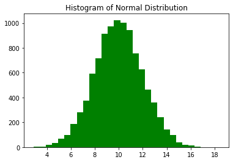

```python
# Simulating a normal distribution centered around 10,
# with a standard deviation of 2
x = np.random.normal(10, 2, size=10000)
plt.figure(figsize=(6, 4))
plt.hist(x, bins=30, facecolor='green')
plt.title('Histogram of Normal Distribution')
plt.show()
```

Again, one can display more than one distribution, calling more than one `plt.hist()`:

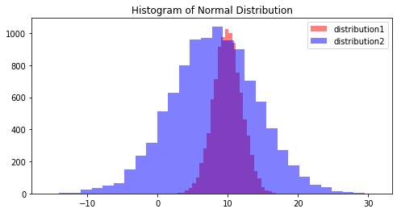

```python
y = np.random.normal(8, 6, size=10000)
plt.figure(figsize=(8, 4))
plt.hist(x, bins=30, facecolor='r', label='distribution1', alpha=0.5)
plt.hist(y, bins=30, facecolor='b', label='distribution2', alpha=0.5)
plt.title('Histogram of Normal Distribution')
plt.legend()
plt.show()
```

## III.4. Scatter plot

#### `plt.scatter`

The function `plt.scatter` draws a scatter plot of the given points.

The scatter plot is commonly used when looking for **correlations**, commonly between 2 variables of a set of data. You can also display more variables by coloring the points, or varying the size (Bubble chart).

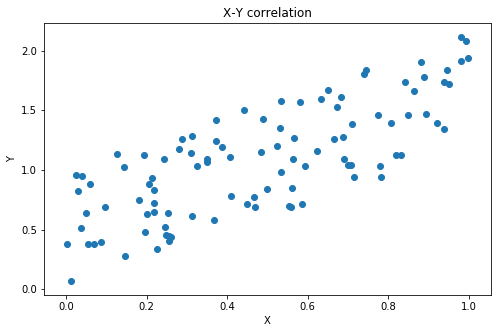

```python
# Data generation
x = np.random.random(size=100)
y = 1.2*x + np.random.random(size=100)
bubble_size = y*3 + np.random.random(size=100)*100

plt.figure(figsize=(8, 5))
plt.scatter(x, y)
plt.xlabel('X')
plt.ylabel('Y')
plt.title('X-Y correlation')
plt.show()
```

One can do a bubble chart by using the size `s` parameter:

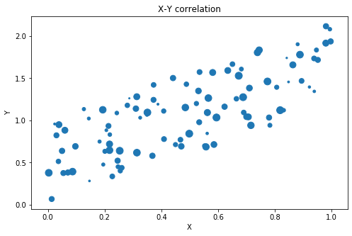

```python
plt.figure(figsize=(8, 5))
plt.scatter(x, y, s=bubble_size)
plt.xlabel('X')
plt.ylabel('Y')
plt.title('X-Y correlation')
plt.show()
```

## Other dataviz tools and softwares

Although very useful, Matplotlib remains pretty basic. Fortunately, there exist much more tools and softwares for more impactful data viz.

Other python libraries:

- Seaborn
- Bokeh
- Plot.ly
- Folium
- ...

Other popular softwares:

- Tableau
- Dataiku
- R++
- Excel
- ...

# IV. Data Exploration with Titanic

Most projects have an exploratory phase of the data.

Here we will have a short introduction to an EDA (Exploratory Data Analysis) on the famous dataset of [Titanic](https://www.kaggle.com/c/titanic/data?select=train.csv).

## IV.1. Loading the data

```python
import pandas as pd

data = pd.read_csv('titanic.csv')
data = data.dropna(subset=['Age'])
data.head()
```

|  | PassengerId | Survived | Pclass | Name | Sex | Age | SibSp | Parch | Ticket | Fare | Cabin | Embarked |
| --- | --- | --- | --- | --- | --- | --- | --- | --- | --- | --- | --- | --- |
| 0 | 1 | 0 | 3 | Braund, Mr. Owen Harris | male | 22.0 | 1 | 0 | A/5 21171 | 7.2500 | NaN | S |
| 1 | 2 | 1 | 1 | Cumings, Mrs. John Bradley (Florence Briggs Th... | female | 38.0 | 1 | 0 | PC 17599 | 71.2833 | C85 | C |
| 2 | 3 | 1 | 3 | Heikkinen, Miss. Laina | female | 26.0 | 0 | 0 | STON/O2. 3101282 | 7.9250 | NaN | S |
| 3 | 4 | 1 | 1 | Futrelle, Mrs. Jacques Heath (Lily May Peel) | female | 35.0 | 1 | 0 | 113803 | 53.1000 | C123 | S |
| 4 | 5 | 0 | 3 | Allen, Mr. William Henry | male | 35.0 | 0 | 0 | 373450 | 8.0500 | NaN | S |

## IV.2. Univariate and Multivariate analysis

When performing data analysis, we usually start by exploring one variable and its distribution, this is what we call **univariate analysis**.

Then, we can explore several variables at a time, to see correlations for example. This is a **multivariate analysis**.

## Gender distribution

For example, we can display the **number of passengers per gender**

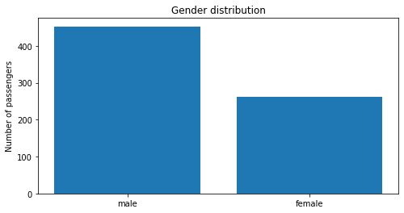

```python
genders = data['Sex'].value_counts()
plt.figure(figsize=(8, 4))
plt.bar(genders.index, genders.values)
plt.title('Gender distribution')
plt.ylabel('Number of passengers')
plt.show()
```

We can also watch the **survival rate per gender**

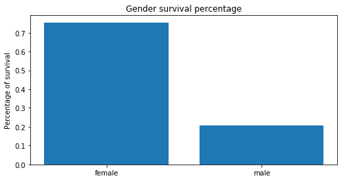

```python
survival = data.groupby('Sex')['Survived'].mean()
plt.figure(figsize=(8, 4))
plt.bar(survival.index, survival.values)
plt.title('Gender survival percentage')
plt.ylabel('Percentage of survival')
plt.show()
```

What would you conclude?

## IV.3. Age distribution

Let's explore the age distribution.

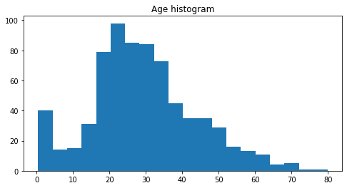

```python
plt.figure(figsize=(8, 4))
plt.hist(data['Age'], bins=20)
plt.title('Age histogram')
plt.show()
```

Now let's plot distribution depending on survival.

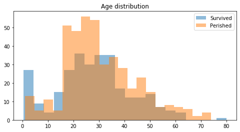

```python
plt.figure(figsize=(8, 4))
plt.hist(data[data['Survived']==1]['Age'], bins=20, alpha=0.5, label='Survived')
plt.hist(data[data['Survived']==0]['Age'], bins=20, alpha=0.5, label='Perished')
plt.title('Age distribution')
plt.legend()
plt.show()
```

How to conclude on that?

It does not seem like the best way of displaying this data... How could we do?

```python
def split_age_group(x):
    idx_group = int(x // 10)
    name_group = "{} to {}".format(idx_group*10, (idx_group+1)*10)
    return name_group

data["Age_group"] = data["Age"].apply(split_age_group)

survival = data.groupby("Age_group")["Survived"].mean()
print(survival)
```

```
Age_group
0 to 10     0.612903
10 to 20    0.401961
20 to 30    0.350000
30 to 40    0.437126
40 to 50    0.382022
50 to 60    0.416667
60 to 70    0.315789
70 to 80    0.000000
80 to 90    1.000000
Name: Survived, dtype: float64
```

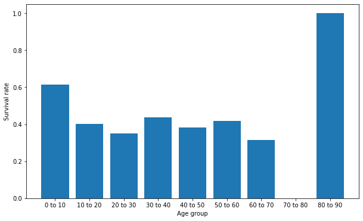

```python
plt.figure(figsize=(10, 6))
plt.bar(survival.index, survival.values)
plt.ylabel('Survival rate')
plt.xlabel('Age group')
plt.show()
```

Here the picture is more clear: you has more chances to survive below 10 y.o., and above 80 (though the statistical significance of this point is arguable...).

## Conclusion on EDA

The EDA is a really important part of any data related project. Here are some of the questions to ask while doing the EDA:

- What are my features?
- Are there any missing data?
- Are there any outliers in some features?
- Are there correlations between two or more features?